# ETM 58D Homework 2

Gulnur Acar & Cagatay Yurdasal

23 Nisan 2019

# Task 1

In this part, we were supposed to understand if we can obtain significant information regarding the game outcomes using the odd data from multiple bookmakers. To examine this data, match results and the odds of some selected bookmakers. We followed the steps below;

- Cleaned data inconsistencies
- Strings pointing the same teams are unified
- The matches which have no results in data are removed
- The matches which are postponed are removed
- Epoch data converted into readable timestamps
- Scores are converted from strings to divided integers
- Results in terms of total goals are calculated
- 5 bookmakers are chosen; ‘BetVictor’, ‘10Bet’, ‘bwin’, ‘bet365’ and ‘Unibet’
- Total handicup is set to value of 2.5
- Final odds are selected to examine the change in success

## Part A

The principal component analysis (PCA) is performed on the data The below graphics are follwing; ‘PCA of BetVictor’, ‘PCA of 10Bet’, ‘PCA of bwin’, ‘PCA of bet365’ and ‘PCA of Unibet’

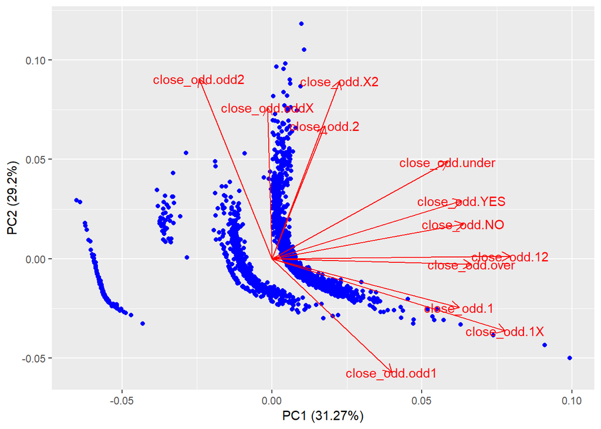

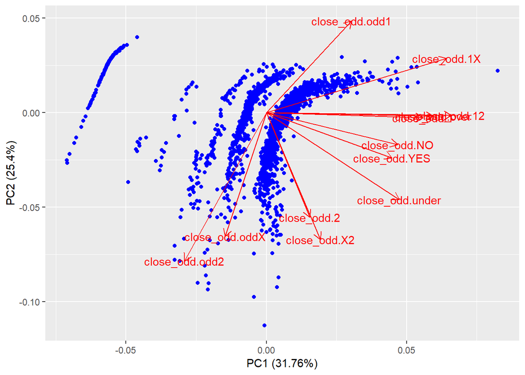

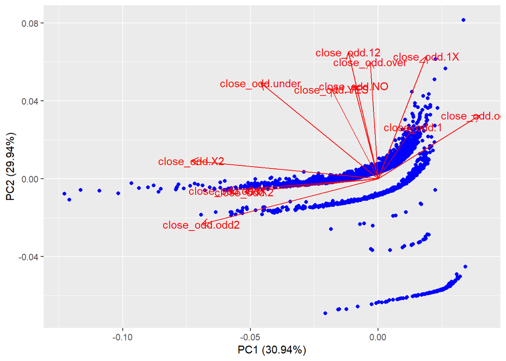

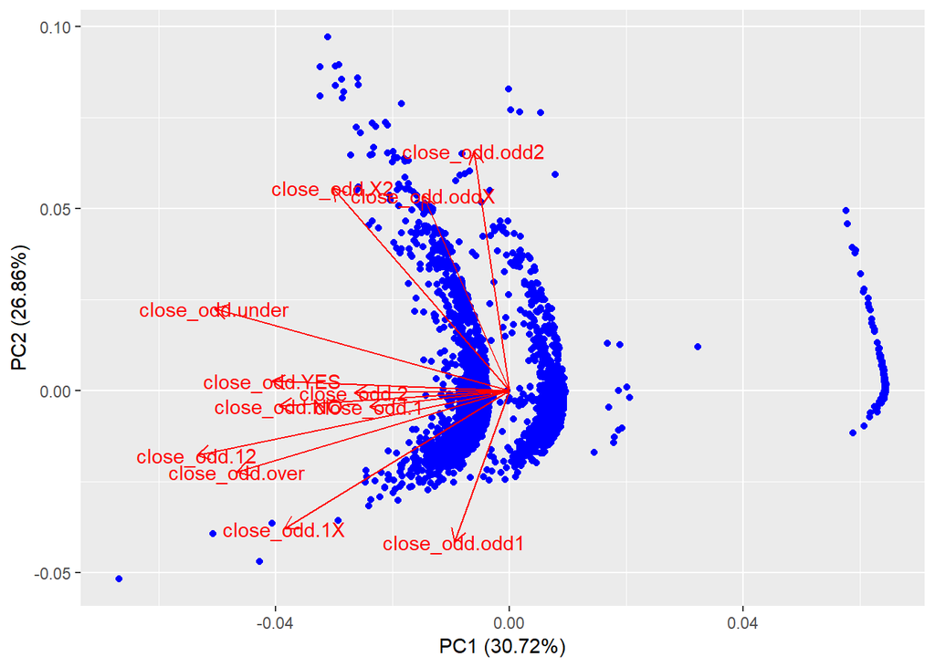

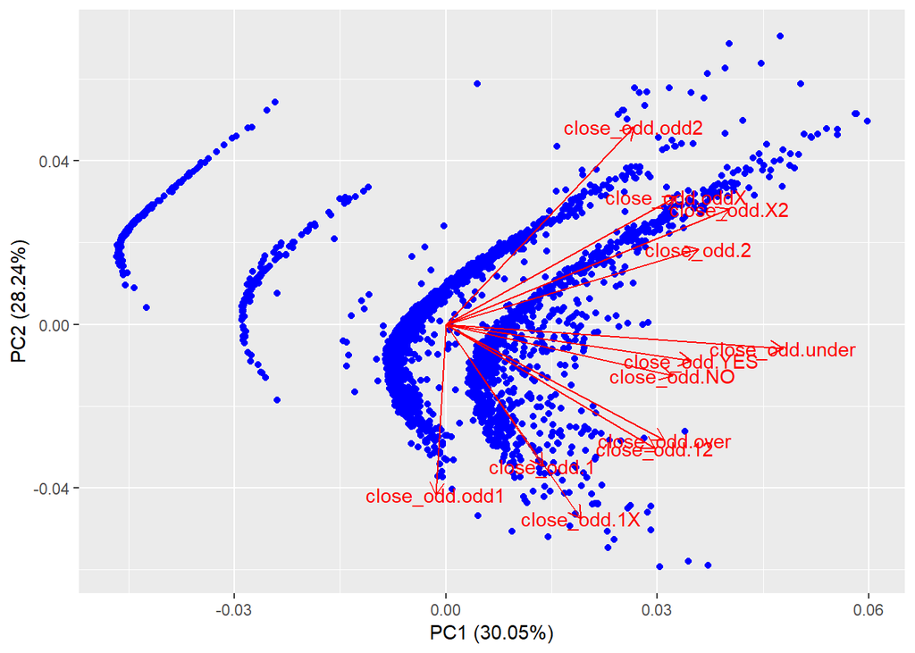

There were null values in the data, these null values are changed with the value of 0 to analyze data with PCA, because of that, the result data is neared to 0 value.

## Task B

In this part, we do MDS analysis.

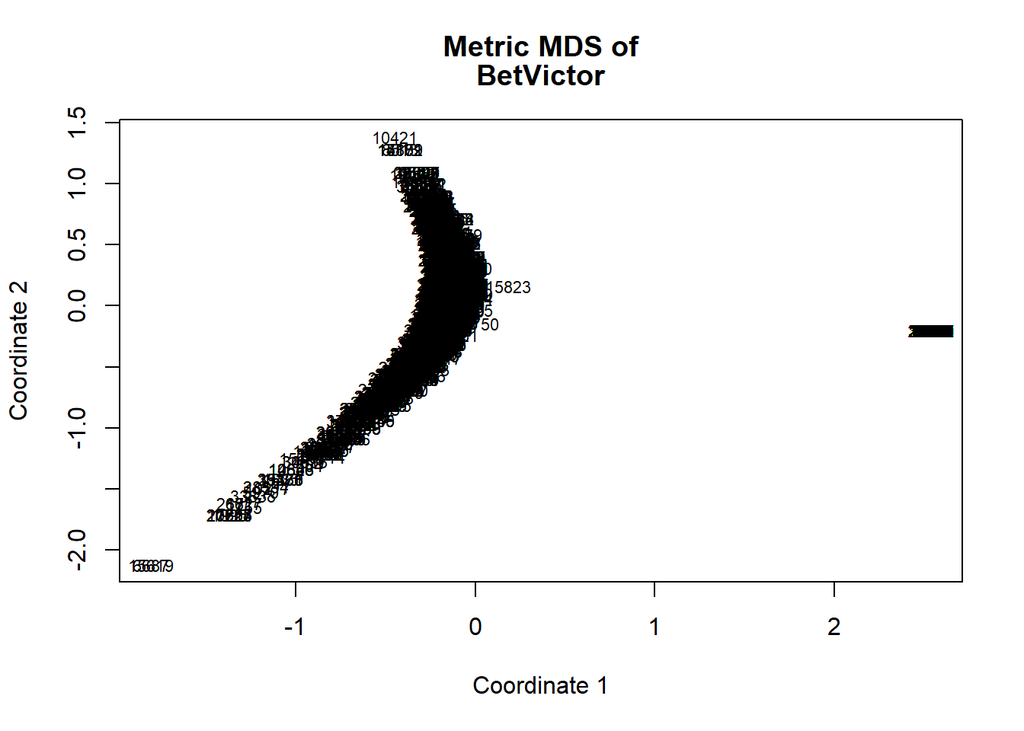

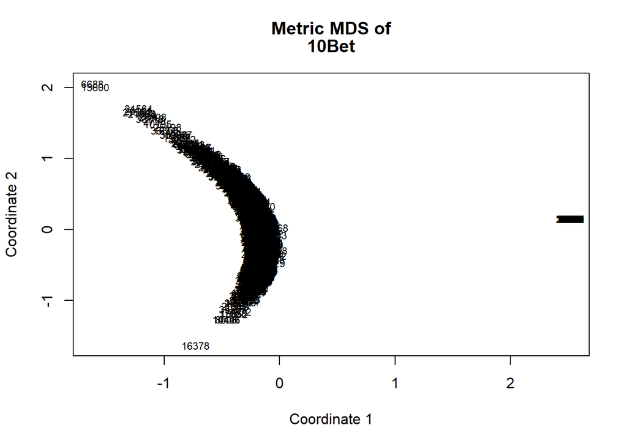

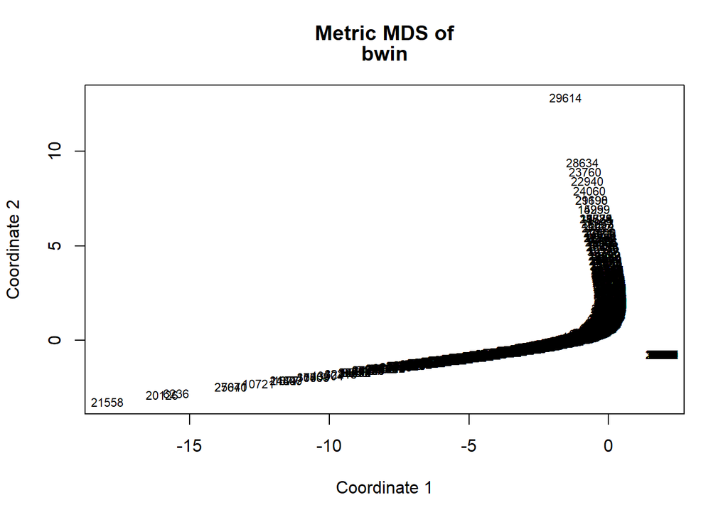

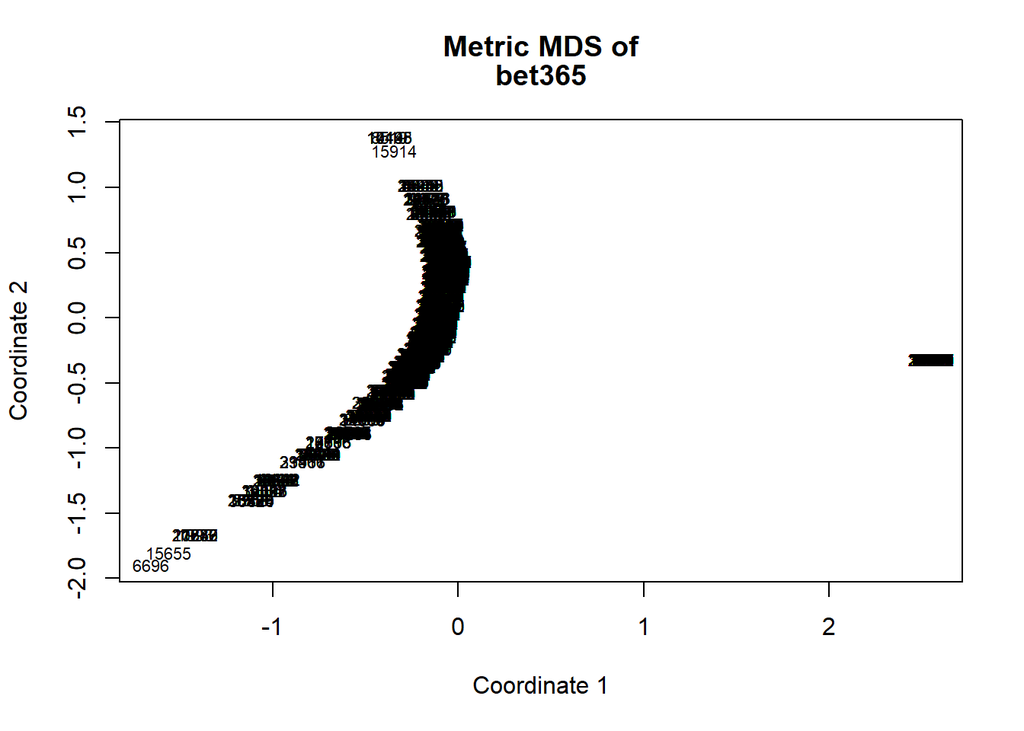

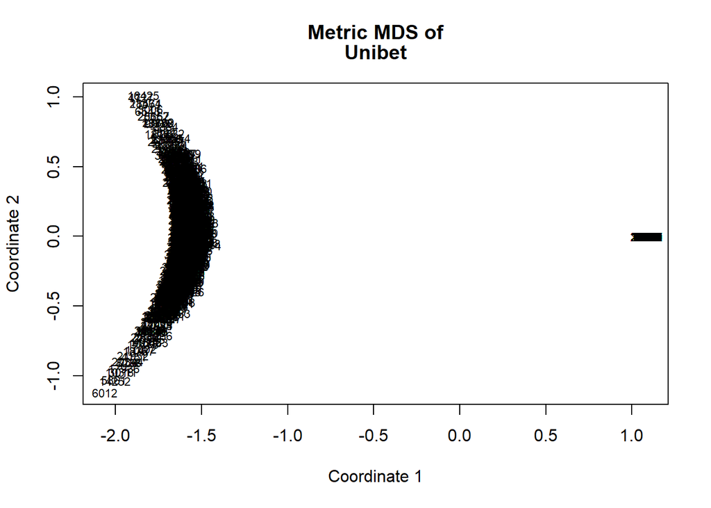

## Part 3

PCA analysis shows how effective and to what extent vectors affect the result, while MDS analysis shows the interaction between two vectors with the highest contribution. These two analyzes are the analyzes that can be selected according to our purpose. Pca eigenvectors by selecting what factor to use allows you to choose. MDS shows the magnitude of the values.

# Task 2

In this part of the homework 2, the logistic regression model is builded to predict if a game ends as over or under.

For this purpose, We followed the steps below;

- The data of feature_extraciton and data_preprocessing corrected and prepared to prediction.
- The date of testStart and trainStart are determined.
- Threshold is set to 0.01 value.
- Null values in data have been eliminated

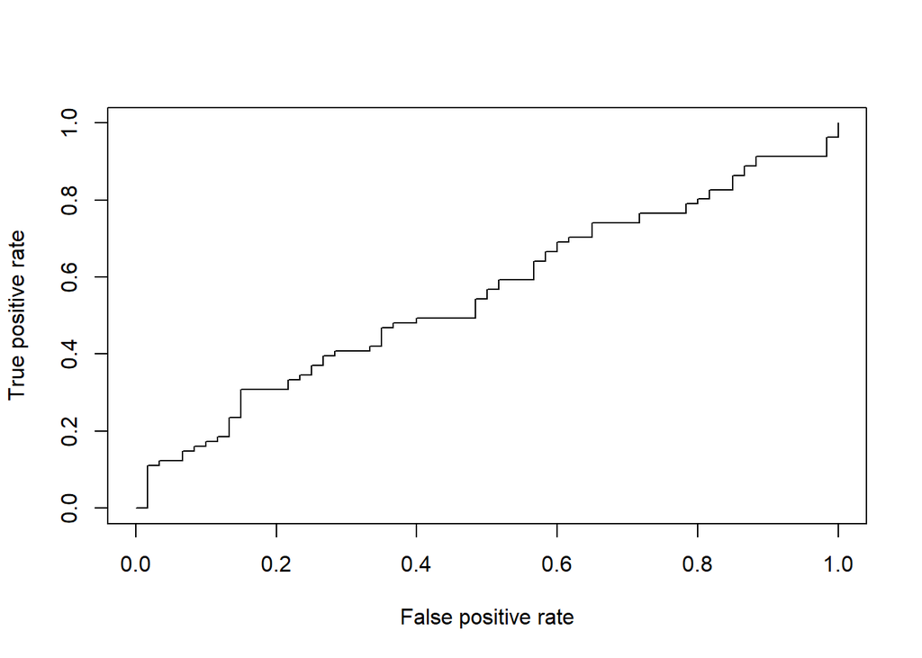

# Appendix

## r code

```
TASK 1

# Init files----
#
require(data.table)
require(lubridate)
require(ggplot2)
require(ggfortify)
require(tidyimpute)
library(data.table)
library(lubridate)
library(ggplot2)
library(ggfortify)
library(tidyimpute)


setwd("C:\\Users\\TCGACAR\\Documents\\ETM\\ETM-58D-BUSINESS ANALYTICS\\Homework 2")
# read matches info
matches=readRDS('df9b1196-e3cf-4cc7-9159-f236fe738215_matches.rds')
# read odds data
odds=readRDS('df9b1196-e3cf-4cc7-9159-f236fe738215_odd_details.rds')

# Data corrections----
# delete these column
matches$type=NULL
matches$leagueId=NULL

# fix home teams
matches[home=='manchester-city',home:='manchester city']
matches[home=='crystal-palace',home:='crystal palace']
matches[home=='newcastle utd',home:='newcastle']
matches[home=='stoke',home:='stoke city']
matches[home=='west-ham',home:='west ham']
matches[home %in% c('manchester-united','manchester-utd'), home:='manchester united']

# fix away teams
matches[away=='manchester-city',away:='manchester city']
matches[away=='crystal-palace',away:='crystal palace']
matches[away=='newcastle utd',away:='newcastle']
matches[away=='stoke',away:='stoke city']
```

[output cut: 144 more lines]

```
train_features <- train_features[,-(1:4)]

# DATA CORRECTION

test_features <- test_features[!is.na(Result_Total)]

# MODELLING

model=glm(Result_Total~.,data=train_features,family="binomial")
summary(model)
p=predict(model, newdata = test_features,type = "response")
pr <- prediction(p, as.numeric(test_features$Result_Total))
# TPR = sensitivity, FPR=specificity
prf <- performance(pr, measure = "tpr", x.measure = "fpr")
plot(prf)
```